# Practical Machine Learning Project: Prediction Assignment

Pablo

January 14, 2018

# 1. Executive Summary

By using devices such as Jawbone Up, Nike FuelBand, and Fitbit is now possible to collect a large amount of data about personal activity relatively inexpensively. This type of devices are part of the quantified self-movement - a group of enthusiasts who take measurements about themselves regularly to improve their health, to find patterns in their behavior, or because they are tech geeks. One thing that people regularly do is to quantify how much of a particular activity they do, but they rarely quantify how well they do it. Based on data collected from such devices accelerometers, this document presents how several models were built to predict the manner in which people using such devices do a particular activity. Six young health participants were asked to perform one set of 10 repetitions of the Unilateral Dumbbell Biceps Curl in five different fashions classified as classes. Class A when the activity is conducted exactly according to the specification, Class B when throwing the elbows to the front, Class C if the participant is lifting the dumbbell only halfway, Class D if the dumbbell is lowered only halfway and Class E when the participant is throwing the hips to the front. This document presents the results of several models aiming to predict previous behavior; the best model is chosen, explaining the reasons supporting the selection; the picked model is run once on the testing set, getting some prediction results for this data set.

# 2. Loading and Processing the Data

The first step is to load and clean the data. The strategy for building the prediction model and not overfitting it to the training set will be to split the training set into two subsets, having 70% of the data for training purposes and the remaining as the test set.

```r
library(RColorBrewer)
library(knitr)
library(caret)
```

```r
library(rpart)
library(rpart.plot)
library(randomForest)
library(corrplot)
library(ggplot2)
library(knitr)
library(rattle)
library(RGtk2Extras)
# Download the training and test sets
training <- read.csv(url("https://d396qusza40orc.cloudfront.net/predmachlearn/pml-training.csv"))
testing  <- read.csv(url("https://d396qusza40orc.cloudfront.net/predmachlearn/pml-testing.csv"))
```

After loading the data some data cleansing is conducted to remove the mostly NA and near zero variance variables. Likewise, the first seven column variables are removed as they do not contain information relevant to the analysis to be carried out.

```r
# Data cleaning
NZV <- nearZeroVar(training)
training <- training [, -NZV]
NZV <- nearZeroVar(testing)
testing <- testing [, -NZV]
Mostly_NA<- sapply(training, function(x) mean(is.na(x))) > 0.95
training <- training[, Mostly_NA==FALSE]
Mostly_NA<- sapply(testing, function(x) mean(is.na(x))) > 0.95
testing <- testing[, Mostly_NA==FALSE]
training <- training[, -c(1:7)]
testing <- testing[, -c(1:7)]
dim(training)
```

```
## [1] 19622    52
```

```r
dim(testing)
```

```
## [1] 20 52
```

After the cleansing process, both datasets end up having 52 column variables, the training set will have 19,622 observations (ie. rows) and the testing set 20. The next step is to create the 70%/30% partition on the training set, aiming to be able to conduct some pre-testing on the models, without using the actual testing set to avoid overfitting; the latter data set will be used only once at the end of the analysis when the best prediction model be selected.

```r
# create the partition (70/30) within the training dataset
inTrain  <- createDataPartition(training$classe, p=0.7, list=FALSE)
Train_Set <- training[inTrain, ]
Train_TestSet  <- training[-inTrain, ]
```

# 3. Prediction Models Design

Basically, two predictions models were analyzed (ie. random forest and decision trees), picking only one based on the accuracy results after running the confusion matrix; the chosen model will be applied to the test set. Each model will be built and tested using the training set and then over the 30% subset of the training set, the latter initially used for pre-testing each individual model, helping in the model selection process. The firs prediction model simulated was random forest and then the analysis was conducted using decision trees.

# 3.1 Random Forest

Follows the prediction model using random forest.

```r
# model fit
set.seed(98765)
Forest <- trainControl(method="cv", number=3, verboseIter=FALSE)
Fitting_model_RF <- train(classe ~ ., data=Train_Set, method="rf",
                          trControl=Forest)
Fitting_model_RF$finalModel
```

```
##
## Call:
##  randomForest(x = x, y = y, mtry = param$mtry)
##                Type of random forest: classification
##                      Number of trees: 500
## No. of variables tried at each split: 26
##
##         OOB estimate of  error rate: 0.7%
## Confusion matrix:
##      A    B    C    D    E  class.error
## A 3904    2    0    0    0 0.0005120328
## B   23 2626    7    0    2 0.0120391272
## C    0   14 2371   11    0 0.0104340568
## D    0    1   24 2224    3 0.0124333925
## E    0    0    4    5 2516 0.0035643564
```

```r
# prediction on Test dataset
predict_RForest <- predict(Fitting_model_RF, newdata=Train_TestSet)
conf_Mat_RForest <- confusionMatrix(predict_RForest, Train_TestSet$classe)
conf_Mat_RForest
```

```
## Confusion Matrix and Statistics
##
##           Reference
## Prediction    A    B    C    D    E
##          A 1672   12    0    0    0
##          B    1 1123    3    0    0
##          C    0    3 1023   15    1
##          D    0    1    0  948    5
##          E    1    0    0    1 1076
##
## Overall Statistics
##
##                Accuracy : 0.9927
##                  95% CI : (0.9902, 0.9947)
##     No Information Rate : 0.2845
##     P-Value [Acc > NIR] : < 2.2e-16
##
##                   Kappa : 0.9908
##  Mcnemar's Test P-Value : NA
##
## Statistics by Class:
##
##                      Class: A Class: B Class: C Class: D Class: E
## Sensitivity            0.9988   0.9860   0.9971   0.9834   0.9945
## Specificity            0.9972   0.9992   0.9961   0.9988   0.9996
## Pos Pred Value         0.9929   0.9965   0.9818   0.9937   0.9981
## Neg Pred Value         0.9995   0.9966   0.9994   0.9968   0.9988
## Prevalence             0.2845   0.1935   0.1743   0.1638   0.1839
## Detection Rate         0.2841   0.1908   0.1738   0.1611   0.1828
## Detection Prevalence   0.2862   0.1915   0.1771   0.1621   0.1832
## Balanced Accuracy      0.9980   0.9926   0.9966   0.9911   0.9970
```

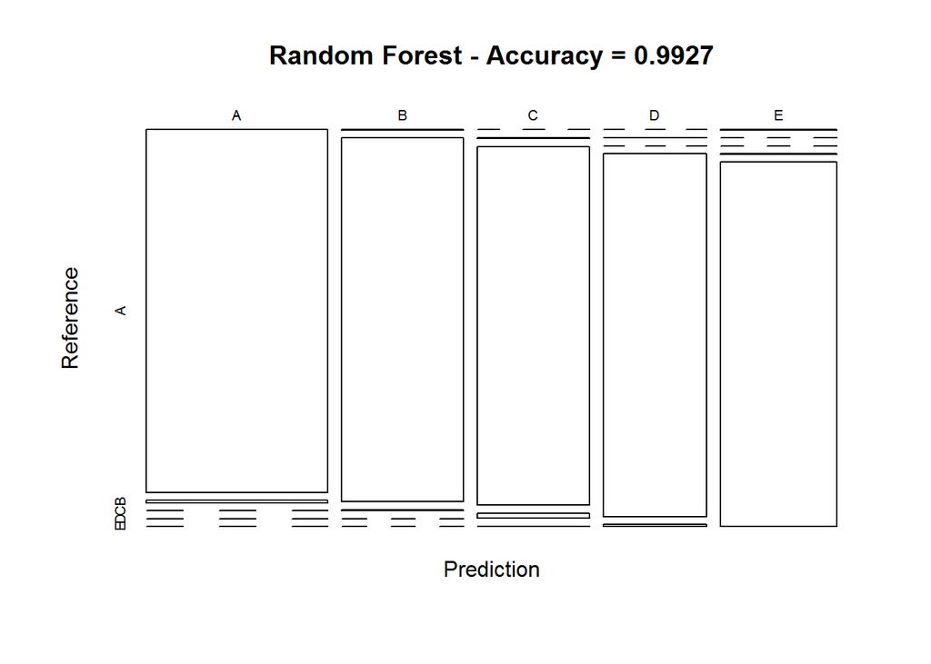

```r
# plot matrix results
plot(conf_Mat_RForest$table, col = conf_Mat_RForest$byClass,
     main = paste("Random Forest - Accuracy =",
                  round(conf_Mat_RForest$overall['Accuracy'], 4)))
```

# 3.2 Decision Trees

Follows the prediction model using desicion trees.

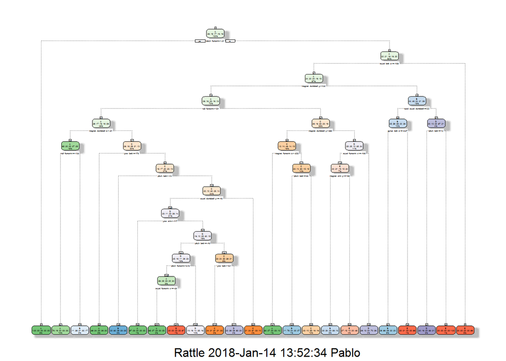

```r
# model fit
set.seed(98765)
Dec_Tree_Mod_Fit <- rpart(classe ~ ., data=Train_Set, method="class")
fancyRpartPlot(Dec_Tree_Mod_Fit)
```

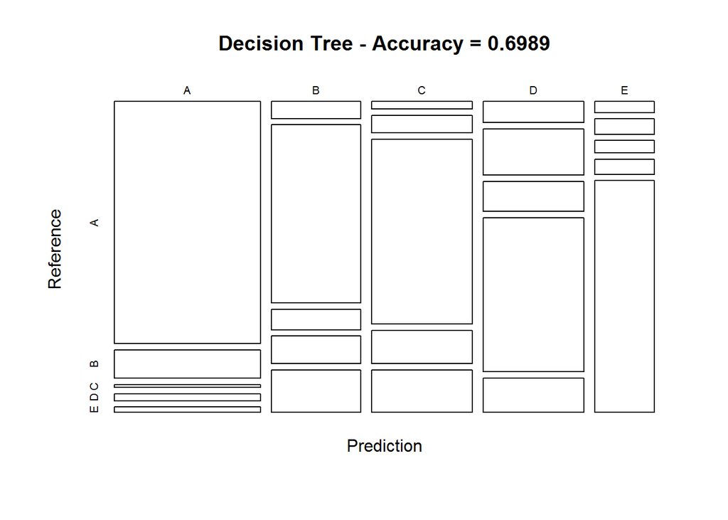

```r
# prediction on Test dataset
Predict_Dec_Tree <- predict(Dec_Tree_Mod_Fit, newdata=Train_TestSet, type="class")
conf_Mat_Dec_Tree <- confusionMatrix(Predict_Dec_Tree, Train_TestSet$classe)

# plot matrix results
plot(conf_Mat_Dec_Tree$table, col = conf_Mat_Dec_Tree$byClass,
     main = paste("Decision Tree - Accuracy =",
                  round(conf_Mat_Dec_Tree$overall['Accuracy'], 4)))
```

# 3. Conclusion

```r
Final_Prediction <- predict(Fitting_model_RF, newdata=testing)
Final_Prediction
```

```
##  [1] B A B A A E D B A A B C B A E E A B B B
## Levels: A B C D E
```

Follows the source for some of the comments made in the executive summary and for the dataset: http://web.archive.org/web/20161224072740/http:/groupware.les.inf.puc-rio.br/har.